# Mechanisms through which exercise reduces symptom severity and/or functional impairment in posttraumatic stress disorder (PTSD)

Simonne Wright

2023-12-07

# Results

## Flow of Study Selection and Descriptives

For the studies included in the meta-analyses, the earliest studies were performed in 2014, while the most recent studies were performed in 2023. The median sample size across the studies was 58 participants per study. The median of the mean participant age was 37 years (ranging from 29 to 50 years).

## Meta-analysis of PTSD Symptom Severity (Primary Outcome)

### Post-intervention (weeks)

8 studies provided data for PTSD symptom severity and contributed 8 effect measures to the PTSD symptom severity meta-analysis. The summary for PTSD symptom severity is shown in Figure 2. The meta-analysis found no significant difference in PTSD symptom severity between exercise and comparison groups, g = −0.09, 95% CI [−0.24, 0.07], p = .286. Although the I2 value (0%) suggests there was no heterogeneity, some heterogeneity can be seen when inspecting the width of the prediction intervals.

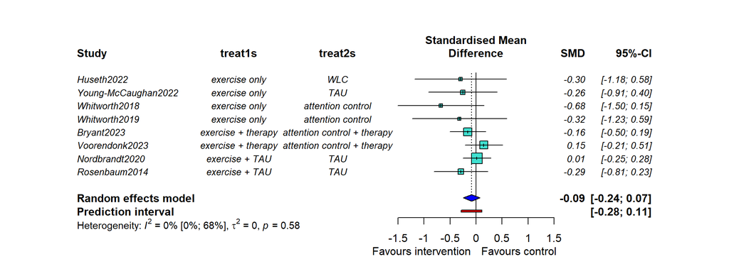

**Figure 2:** Meta-analysis of the effects of exercise on PTSD symptom severity.

## Subgroup Analyses and Meta-regressions

We explore whether heterogeneity could be potentially explained by differences in study-level characteristics using subgroup analyses and meta-regression below.T he following characteristics were explored as sources of heterogeneity for the primary outcome, PTSD symptom severity:

- Exercise intensity (moderate intensity vs high intensity)
- Specific exercise type (aerobic vs. anaerobic vs. mixed)
- Exercise augmented by TAU/therapy (exercise only vs. therapy/tau)
- Intervention length (weeks)

### Subgroup analysis by exercise intensity

There was no significant difference in PTSD symptom severity between studies with moderate intensity and those with high intensity exercise groups (p = .067; see Figure 3).

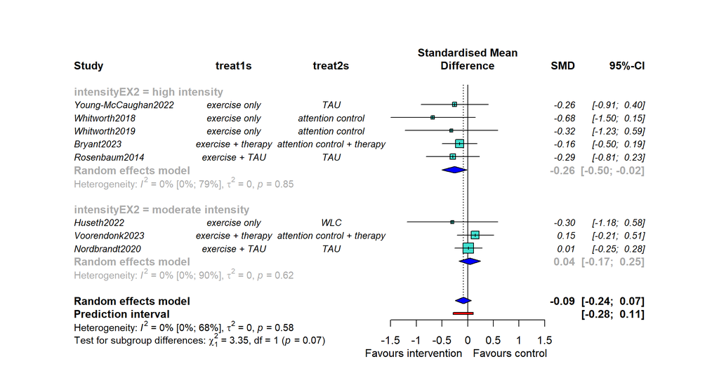

**Figure 3:** Sub-group analysis of the effects of exercise on PTSD symptom severity by exercise intensity

### Subgroup analysis by specific exercise type

There was no significant difference in PTSD symptom severity between studies with aerobic or anaerobic or mixed exercise groups (p = .191; see Figure 4).

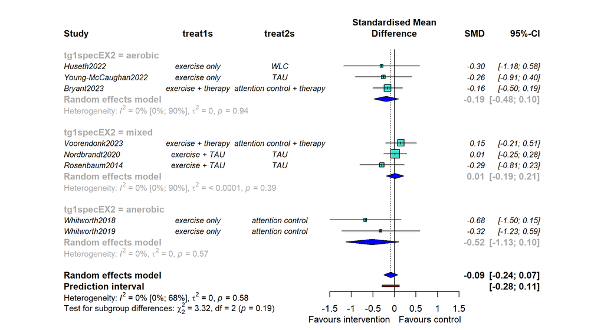

**Figure 4:** Sub-group analysis of the effects of exercise on PTSD symptom severity by specific exercise type

### Subgroup analysis by exercise alone or tau/therapy augmented by exercise

There was no significant difference in PTSD symptom severity between studies with exercise alone or tau/therapy augmented by exercise (p = .122; see Figure 5).

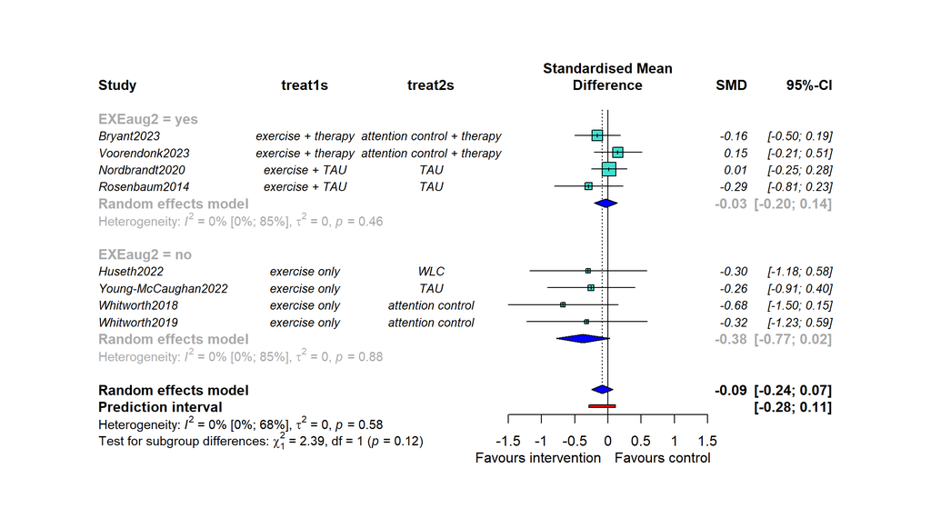

**Figure 5:** Sub-group analysis of the effects of exercise on PTSD symptom severity by exercise alone or tau/therapy augmented by exercise

### Meta-regression by intervention length

Overall, the influence of intervention length on the treatment effect did not reach statistical significance intervention length (p = .136; see Figure 6)

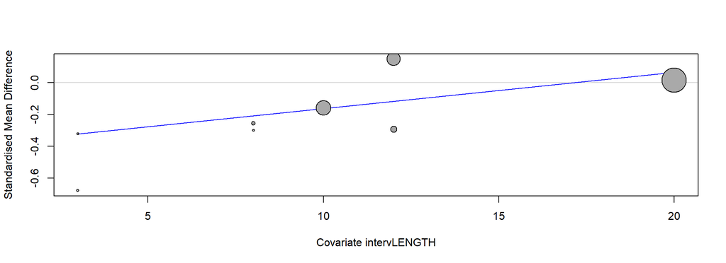

**Figure 6:** Meta-regression of the effects of exercise on PTSD symptom severity by intervention length

## Meta-analysis of Treatment Dropout (secondary outcome)

### Post-intervention (weeks)

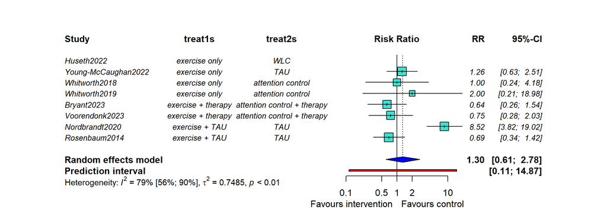

**Figure 7:** Meta-analysis of the effects of exercise on treatment dropout

## Reporting Bias

Visual inspection of the funnel plot of standard error Hedges’ g suggested possible publication bias in favour the of exercise group (n = 8). There was insufficient studies to test for small study effect.

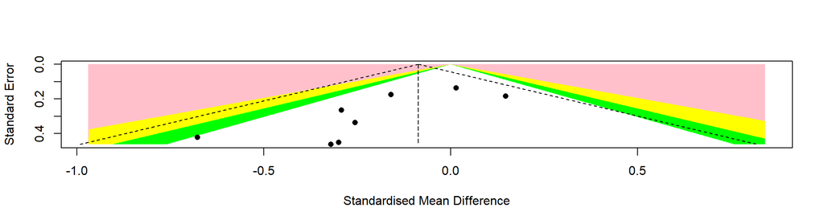

**Figure 8:** Funnel plot of all studies included in the meta-analyses